# Supplementary R code for the manuscript:

Forget the audience: tadpoles release similar disturbance cues regardless of kinship or familiarity

Kevin R Bairos-Novak

Document last run on 2020-09-02

# 1 Three-way (cue x familiarity x kinship) analysis

For the first analysis, we examine only undisturbed or disturbance cues and exclude the control water (‘W’) cue, as it lacks familiarity and kinship distinctions. For this analysis, pre-cue exposure numbers of line crosses are modelled based on a possible three-way interaction between cue type (undisturbed or disturbance cue), familiarity type (familiar or unfamiliar), and kinship type (kin or non-kin).

## 1.1 Pre-exposure analysis

Due to a high overdispersion parameter, we model counts of pre-exposure line crosses using a quasipoisson GLM. We initially use Type I SS estimates from the `summary()` function to determine the most significant parameter estimates, then use the `drop1()` function to obtain Type III estimates for our final reporting, which are more accurate than Type I SS when the order of model factor inputs is not important.

```r
cat("Using summary (type I SS):")
```

```
Using summary (type I SS):
```

```r
(m1.pre <- data %>%
    filter(cue!="W") %>% # remove water cues
    glm(data=., pre ~ cue * familiarity * kinship, family=quasipoisson)) %>%
    summary # significant familiarity x kinship iteraction, no other significant factors
```

```
Call:
glm(formula = pre ~ cue * familiarity * kinship, family = quasipoisson,
    data = .)

Deviance Residuals:
    Min       1Q   Median       3Q      Max
-3.6869  -1.7792  -0.4557   1.0902   6.4765

Coefficients:
                            Estimate Std. Error t value Pr(>|t|)
(Intercept)                 2.945757   0.032280  91.257   <2e-16 ***
cue1                        0.008596   0.032280   0.266   0.7902
familiarity1               -0.012083   0.032280  -0.374   0.7085
kinship1                   -0.022505   0.032280  -0.697   0.4864
cue1:familiarity1           0.005132   0.032280   0.159   0.8738
cue1:kinship1              -0.002305   0.032280  -0.071   0.9431
familiarity1:kinship1       0.071043   0.032280   2.201   0.0287 *
cue1:familiarity1:kinship1  0.021268   0.032280   0.659   0.5106
---
Signif. codes:  0 '***' 0.001 '**' 0.01 '*' 0.05 '.' 0.1 ' ' 1

(Dispersion parameter for quasipoisson family taken to be 4.875471)

    Null deviance: 1101.2  on 246  degrees of freedom
Residual deviance: 1071.6  on 239  degrees of freedom
AIC: NA

Number of Fisher Scoring iterations: 4
```

```r
# kappa dispersion parameter = 4.875471

cat("Using drop1 (type III SS):")
```

```
Using drop1 (type III SS):
```

```r
m1.pre %>% drop1("familiarity:kinship", test="F") # F(1,239) = 5.28, P = 0.023
```

|  | Df | Deviance | F value | Pr(>F) |
| --- | --- | --- | --- | --- |
|  | NA | 1071.606 | NA | NA |
| familiarity:kinship | 1 | 1095.269 | 5.277694 | 0.0224654 |

```r
m1.pre %>% drop1("kinship", test="F") # F(1,239) ≤ 0.52, P ≥ 0.47)
```

|  | Df | Deviance | F value | Pr(>F) |
| --- | --- | --- | --- | --- |
|  | NA | 1071.606 | NA | NA |
| kinship | 1 | 1073.977 | 0.5287941 | 0.467826 |

A significant interaction ($F_{1,239}$ = 5.28, $p$ = 0.023) between familiarity and kinship warrants data splitting by both factors.

#### 1.1.0.1 **Pre-exposure analysis split by kinship**

**Only kin treatments:**

```r
## only kin treatments:
cat("Using summary (type I SS):")
```

```
Using summary (type I SS):
```

```r
data %>% filter(cue!="W" & kinship == "kin") %>%
    glm(data=., pre  ~ cue * familiarity, family=quasipoisson) %>%
    summary
```

```
Call:
glm(formula = pre ~ cue * familiarity, family = quasipoisson,
    data = .)

Deviance Residuals:
    Min       1Q   Median       3Q      Max
-3.4363  -1.7537  -0.4557   1.1281   6.4765

Coefficients:
                  Estimate Std. Error t value Pr(>|t|)
(Intercept)       2.923251   0.043212  67.648   <2e-16 ***
cue1              0.006291   0.043212   0.146    0.885
familiarity1      0.058959   0.043212   1.364    0.175
cue1:familiarity1 0.026400   0.043212   0.611    0.542
---
Signif. codes:  0 '***' 0.001 '**' 0.01 '*' 0.05 '.' 0.1 ' ' 1

(Dispersion parameter for quasipoisson family taken to be 4.216608)

    Null deviance: 473.12  on 121  degrees of freedom
Residual deviance: 463.29  on 118  degrees of freedom
AIC: NA

Number of Fisher Scoring iterations: 4
```

```r
cat("Using drop1 (type III SS):")
```

```
Using drop1 (type III SS):
```

```r
data %>% filter(cue!="W" & kinship == "kin") %>%
    glm(data=., pre  ~ cue * familiarity, family=quasipoisson) %>%
    drop1("familiarity", test="F")
```

|  | Df | Deviance | F value | Pr(>F) |
| --- | --- | --- | --- | --- |
|  | NA | 463.2860 | NA | NA |
| familiarity | 1 | 471.1548 | 2.004205 | 0.1594976 |

```r
# all F(1,118) ≤ 2.00, P ≥ 0.16
```

All slope parameters are non-significant ($F_{1,118}$ ≤ 2.00, $p$ ≥ 0.16).

**Only non-kin treatments:**

```r
## only non-kin treatments:
cat("Using summary (type I SS):")
```

```
Using summary (type I SS):
```

```r
data %>% filter(cue!="W" & kinship == "non-kin") %>%
    glm(data=., pre  ~ cue * familiarity, family=quasipoisson) %>%
    summary
```

```
Call:
glm(formula = pre ~ cue * familiarity, family = quasipoisson,
    data = .)

Deviance Residuals:
    Min       1Q   Median       3Q      Max
-3.6869  -2.0243  -0.5974   1.0902   5.8983

Coefficients:
                  Estimate Std. Error t value Pr(>|t|)
(Intercept)        2.96826    0.04768  62.251   <2e-16 ***
cue1               0.01090    0.04768   0.229   0.8196
familiarity1      -0.08313    0.04768  -1.743   0.0838 .
cue1:familiarity1 -0.01614    0.04768  -0.338   0.7356
---
Signif. codes:  0 '***' 0.001 '**' 0.01 '*' 0.05 '.' 0.1 ' ' 1

(Dispersion parameter for quasipoisson family taken to be 5.517999)

    Null deviance: 625.95  on 124  degrees of freedom
Residual deviance: 608.32  on 121  degrees of freedom
AIC: NA

Number of Fisher Scoring iterations: 4
```

```r
cat("Using drop1 (type III SS):")
```

```
Using drop1 (type III SS):
```

```r
data %>% filter(cue!="W" & kinship == "non-kin") %>%
    glm(data=., pre  ~ cue * familiarity, family=quasipoisson) %>%
    drop1("familiarity", test="F") # F(1,121) ≤ 3.34, P ≥ 0.070
```

|  | Df | Deviance | F value | Pr(>F) |
| --- | --- | --- | --- | --- |
|  | NA | 608.3196 | NA | NA |
| familiarity | 1 | 625.1104 | 3.339833 | 0.0700855 |

All slope parameters are non-significant ($F_{1,121}$ ≤ 3.34, $p$ ≥ 0.07).

#### 1.1.0.2 **Pre-exposure analysis split by familiarity**

**Only familiar cue treatments:**

```r
## only familiar cue treatments:
cat("Using summary (type I SS):")
```

```
Using summary (type I SS):
```

```r
data %>% filter(cue!="W" & familiarity == "familiar") %>%
    glm(data=., pre  ~ cue * kinship, family=quasipoisson) %>%
    summary
```

```
Call:
glm(formula = pre ~ cue * kinship, family = quasipoisson, data = .)

Deviance Residuals:
    Min       1Q   Median       3Q      Max
-3.4363  -1.7792  -0.5395   0.9567   6.4765

Coefficients:
              Estimate Std. Error t value Pr(>|t|)
(Intercept)    2.93367    0.04531  64.747   <2e-16 ***
cue1           0.01373    0.04531   0.303    0.762
kinship1       0.04854    0.04531   1.071    0.286
cue1:kinship1  0.01896    0.04531   0.419    0.676
---
Signif. codes:  0 '***' 0.001 '**' 0.01 '*' 0.05 '.' 0.1 ' ' 1

(Dispersion parameter for quasipoisson family taken to be 4.895917)

    Null deviance: 556.09  on 126  degrees of freedom
Residual deviance: 549.07  on 123  degrees of freedom
AIC: NA

Number of Fisher Scoring iterations: 4
```

```r
cat("Using drop1 (type III SS):")
```

```
Using drop1 (type III SS):
```

```r
data %>% filter(cue!="W" & familiarity == "familiar") %>%
    glm(data=., pre  ~ cue * kinship, family=quasipoisson) %>%
    drop1("kinship", test="F") # F(1,123) ≤ 1.26, P ≥ 0.26
```

|  | Df | Deviance | F value | Pr(>F) |
| --- | --- | --- | --- | --- |
|  | NA | 549.0706 | NA | NA |
| kinship | 1 | 554.6910 | 1.259053 | 0.2640161 |

All slope parameters are non-significant ($F_{1,123}$ ≤ 1.26, $p$ ≥ 0.26).

**Only unfamiliar cue treatments:**

```r
## only unfamiliar cue treatments:
cat("Using summary (type I SS):")
```

```
Using summary (type I SS):
```

```r
data %>% filter(cue!="W" & familiarity == "unfamiliar") %>%
    glm(data=., pre  ~ cue * kinship, family=quasipoisson) %>%
    summary
```

```
Call:
glm(formula = pre ~ cue * kinship, family = quasipoisson, data = .)

Deviance Residuals:
    Min       1Q   Median       3Q      Max
-3.6869  -1.8008  -0.4154   1.0902   5.8128

Coefficients:
               Estimate Std. Error t value Pr(>|t|)
(Intercept)    2.957840   0.045979  64.330   <2e-16 ***
cue1           0.003463   0.045979   0.075   0.9401
kinship1      -0.093548   0.045979  -2.035   0.0442 *
cue1:kinship1 -0.023573   0.045979  -0.513   0.6091
---
Signif. codes:  0 '***' 0.001 '**' 0.01 '*' 0.05 '.' 0.1 ' ' 1

(Dispersion parameter for quasipoisson family taken to be 4.853792)

    Null deviance: 544.22  on 119  degrees of freedom
Residual deviance: 522.53  on 116  degrees of freedom
AIC: NA

Number of Fisher Scoring iterations: 4
```

```r
cat("Using drop1 (type III SS):")
```

```
Using drop1 (type III SS):
```

```r
data %>% filter(cue!="W" & familiarity == "unfamiliar") %>%
    glm(data=., pre  ~ cue * kinship, family=quasipoisson) %>%
    drop1("kinship", test="F") # F(1,116) = 4.48, P = 0.036
```

|  | Df | Deviance | F value | Pr(>F) |
| --- | --- | --- | --- | --- |
|  | NA | 522.5350 | NA | NA |
| kinship | 1 | 542.7174 | 4.480393 | 0.0364231 |

```r
data %>% filter(cue!="W" & familiarity == "unfamiliar") %>%
    glm(data=., pre  ~ cue * kinship, family=quasipoisson) %>%
    drop1("cue:kinship", test="F") # F(1,116) ≤ 0.28, P ≥ 0.60
```

|  | Df | Deviance | F value | Pr(>F) |
| --- | --- | --- | --- | --- |
|  | NA | 522.5350 | NA | NA |
| cue:kinship | 1 | 523.8101 | 0.2830612 | 0.5957193 |

There is a slight difference in unfamiliar kin vs. non-kin pre-exposure line crosses (kinship: $F_{1,116}$ = 4.48, $p$ ≥ 0.036). Other slope parameters are non-significant ($F_{1,116}$ ≤ 0.28, $p$ ≥ 0.60).

However, after correcting for multiple splits ($\alpha' = 0.025$), there is no significant pre-exposure difference.

```r
main1_pre_lines_summary <- data %>% filter(cue!="W") %>%
    mutate(cue = fct_drop(cue, "W") %>%
            fct_recode("undisturbed cue"="UC", "disturbance cue"="DC")) %>%
    group_by(kinship, familiarity, cue) %>%
    summarise(n = n(),
          mean_lines = mean(pre),
          sd_lines = sd(pre),
          se_lines = sd(pre)/n())
main1_pre_lines_summary
```

| kinship | familiarity | cue | n | mean_lines | sd_lines | se_lines |
| --- | --- | --- | --- | --- | --- | --- |
| kin | familiar | undisturbed cue | 31 | 20.38710 | 9.783242 | 0.3155885 |
| kin | familiar | disturbance cue | 31 | 19.09677 | 8.941867 | 0.2884473 |
| kin | unfamiliar | undisturbed cue | 32 | 17.18750 | 7.706041 | 0.2408138 |
| kin | unfamiliar | disturbance cue | 28 | 17.89286 | 9.064948 | 0.3237481 |
| non-kin | familiar | undisturbed cue | 32 | 17.81250 | 9.956154 | 0.3111298 |
| non-kin | familiar | disturbance cue | 33 | 18.00000 | 9.581884 | 0.2903601 |
| non-kin | unfamiliar | undisturbed cue | 29 | 21.72414 | 11.652396 | 0.4018067 |
| non-kin | unfamiliar | disturbance cue | 31 | 20.58065 | 10.375530 | 0.3346945 |

### 1.1.1 Pre-exposure plot

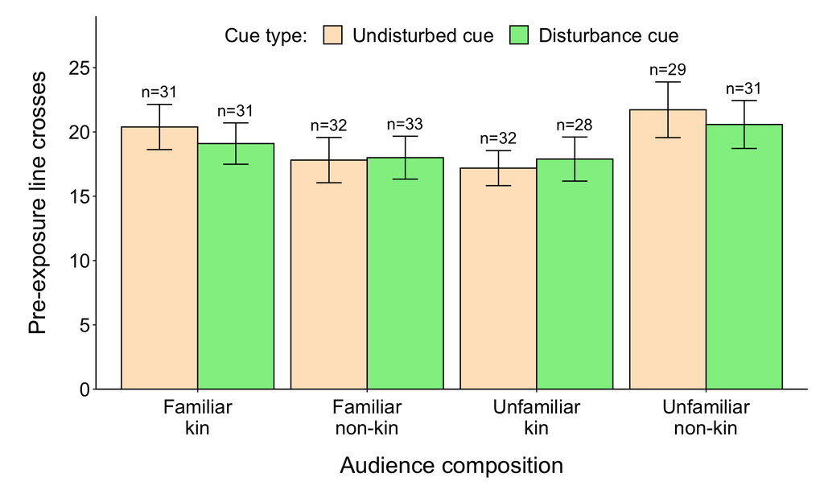

```r
p1.pre <- data %>% filter(cue!="W") %>%
    within({cue <- factor(cue, levels=c("UC","DC"),
                  labels=c("Undisturbed cue", "Disturbance cue"))}) %>%
    mutate(kinfam = interaction(kinship, familiarity)) %>%
    group_by(kinfam, cue) %>%
    summarise(mean = mean(pre, na.rm=T), se = sd(pre, na.rm=T)/sqrt(n()), n = n()) %>%
    ggplot(aes(x = kinfam, y = mean, fill = cue)) +
    ggtheme +
    geom_bar(position=position_dodge(), stat = "identity", col = "black") +
    geom_errorbar(position=position_dodge(width = 0.9), aes(ymin = mean - se, ymax = mean + se),
              width = 0.3) +
    labs(y="Pre-exposure line crosses\n", x=NULL) +
    scale_fill_manual(name = "Cue type: ", labels = c("Undisturbed cue ", "Disturbance cue"),
              values = c("bisque", "light green")) +
    scale_y_continuous(limits = c(0, 29),
               breaks = seq(0,25,by=5),
               expand = c(0,0)) +
    scale_x_discrete(name = "Audience composition", labels = c("Familiar\nkin", "Familiar\nnon-kin", "Unfamiliar\nkin", "Unfamiliar\nnon-kin")) +
    geom_abline(aes(slope=0, intercept=0)) +
    geom_text(aes(y = mean+se+1,
              label=paste0("n=",n,"")),
          position=position_dodge(width=0.9), size=5)
p1.pre
```

Regardless of if there are true differences in the pre-exposure line crosses, we employ a metric in the next section that should be robust to differences in pre-exposure line crosses among treatments.

## 1.2 Proportion change analysis

The proportion change (and percent change) in line crosses to compare the relative change in tadpole activity going from the before cue exposure period ($pre$) to after cue exposure ($post$). To do this, we use a three-way ANOVA (with its parametric assumptions tested in the next section).

$$\begin{aligned}
proportion \; change &= \frac{post - pre}{pre} \\ percent \; change &= \frac{post - pre}{pre} \cdot100\%
\end{aligned}$$

```r
cat("Using summary (type I SS):")
```

```
Using summary (type I SS):
```

```r
(m1.prop <- data %>% filter(cue!="W") %>%
        lm(data=., prop ~ cue * familiarity * kinship)) %>%
    summary # no factors significant except cue type
```

```
Call:
lm(formula = prop ~ cue * familiarity * kinship, data = .)

Residuals:
     Min       1Q   Median       3Q      Max
-0.94009 -0.32767 -0.05954  0.29181  2.34955

Coefficients:
                             Estimate Std. Error t value Pr(>|t|)
(Intercept)                -0.2630514  0.0318234  -8.266 9.62e-15 ***
cue1                        0.1097394  0.0318234   3.448 0.000666 ***
familiarity1                0.0448808  0.0318234   1.410 0.159749
kinship1                    0.0115476  0.0318234   0.363 0.717027
cue1:familiarity1           0.0111937  0.0318234   0.352 0.725340
cue1:kinship1              -0.0230326  0.0318234  -0.724 0.469919
familiarity1:kinship1      -0.0249844  0.0318234  -0.785 0.433174
cue1:familiarity1:kinship1 -0.0008534  0.0318234  -0.027 0.978627
---
Signif. codes:  0 '***' 0.001 '**' 0.01 '*' 0.05 '.' 0.1 ' ' 1

Residual standard error: 0.4995 on 239 degrees of freedom
Multiple R-squared:  0.06098,   Adjusted R-squared:  0.03348
F-statistic: 2.217 on 7 and 239 DF,  p-value: 0.03358
```

```r
cat("Using drop1 (type III SS):")
```

```
Using drop1 (type III SS):
```

```r
m1.prop %>% drop1("cue", test="F") # F(1,239) = 11.89, P = 0.0007
```

|  | Df | Sum of Sq | RSS | AIC | F value | Pr(>F) |
| --- | --- | --- | --- | --- | --- | --- |
|  | NA | NA | 59.63125 | -335.0385 | NA | NA |
| cue | 1 | 2.96694 | 62.59819 | -325.0450 | 11.89139 | 0.0006663 |

```r
m1.prop %>% drop1("familiarity", test="F") # F(1,239) ≤ 1.99, P ≥ 0.16
```

|  | Df | Sum of Sq | RSS | AIC | F value | Pr(>F) |
| --- | --- | --- | --- | --- | --- | --- |
|  | NA | NA | 59.63125 | -335.0385 | NA | NA |
| familiarity | 1 | 0.4962545 | 60.12751 | -334.9915 | 1.988971 | 0.1597486 |

```r
## Analysis on post - pre difference ##
# Not run: same analysis, using difference in line crosses instead of proportion line crosses
cat("Using summary (type I SS):")
(m1.diff <- data %>% filter(cue!="W") %>%
        lm(data=., diff ~ cue * familiarity * kinship)) %>%
    summary # same outcome

cat("Using drop1 (type III SS):")
m1.diff %>% drop1("cue", test="F") # F(1,239) = 11.35, P = 0.0009
m1.diff %>% drop1("familiarity", test="F") # F(1,239) ≤ 2.77, P ≥ 0.097
```

### 1.2.1 Parametric assumptions

Next, we test the normality and homogeneity of variances for the ANOVA model by assessing the distribution of model residuals.

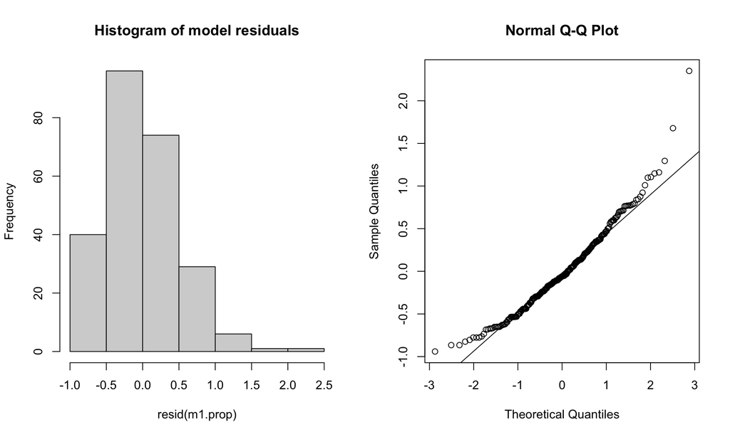

```r
# normality:
par(mfrow=c(1,2))
hist(resid(m1.prop), main="Histogram of model residuals")
qqnorm(resid(m1.prop)); qqline(resid(m1.prop))
```

```r
ks.test(resid(m1.prop), "pnorm", mean = mean(resid(m1.prop)), sd = sd(resid(m1.prop)))
```

```
    One-sample Kolmogorov-Smirnov test

data:  resid(m1.prop)
D = 0.067608, p-value = 0.2089
alternative hypothesis: two-sided
```

```r
# homoscedasticity:
data %>% car::leveneTest(prop  ~ cue * familiarity * kinship, data=.)
```

|  | Df | F value | Pr(>F) |
| --- | --- | --- | --- |
| group | 11 | 0.8996312 | 0.5408691 |
|  | 361 | NA | NA |

Despite the slight skew in the residuals, the data are roughly normally-distributed (Kolmogorov-Smirnov test, D = 0.068, $p$ = 0.21), and ANOVA procedures are relatively robust to deviances from normality [Kirk, RE (1995). Experimental Design: Procedures For The Behavioral Sciences (3 ed.). Pacific Grove, CA, USA: Brooks/Cole].

Further, the assumption of homoscedasticity is upheld (Levene’s $F_{11,361}$ = 0.90. $p$ = 0.54)

### 1.2.2 Effect sizes

```r
main1_prop_summary <- data %>% filter(cue!="W") %>%
    mutate(cue = fct_drop(cue, "W") %>%
            fct_recode("undisturbed cue"="UC", "disturbance cue"="DC")) %>%
    pivot_longer(cols=pre:prop) %>%
    group_by(familiarity, kinship, cue, name) %>%
    summarise(n = n(),
          mean = mean(value, na.rm=T),
          se = sd(value, na.rm=T)/sqrt(n())) %>%
    pivot_wider(id_cols=c(familiarity:cue, n),
            names_from=name, values_from=c(mean,se), names_sort=T) %>%
    relocate(c(mean_pre, se_pre), .after=n) %>%
    relocate(c(mean_post, se_post), .after=se_pre) %>%
    relocate(c(mean_prop, se_prop), .after=se_post)
main1_prop_summary
```

| familiarity | kinship | cue | n | mean_pre | se_pre | mean_post | se_post | mean_prop | se_prop | mean_diff | se_diff |
| --- | --- | --- | --- | --- | --- | --- | --- | --- | --- | --- | --- |
| familiar | kin | undisturbed cue | 31 | 20.38710 | 1.757122 | 18.51613 | 2.427385 | -0.1345604 | 0.0866650 | -1.870968 | 1.576536 |
| familiar | kin | disturbance cue | 31 | 19.09677 | 1.606007 | 13.19355 | 1.870782 | -0.3286545 | 0.0807828 | -5.903226 | 1.617349 |
| familiar | non-kin | undisturbed cue | 32 | 17.81250 | 1.760016 | 15.62500 | 1.968886 | -0.0599147 | 0.0933185 | -2.187500 | 1.725308 |
| familiar | non-kin | disturbance cue | 33 | 18.00000 | 1.667992 | 10.33333 | 1.422004 | -0.3495528 | 0.1004747 | -7.666667 | 1.982244 |
| unfamiliar | kin | undisturbed cue | 32 | 17.18750 | 1.362248 | 14.37500 | 1.949333 | -0.1950336 | 0.0942960 | -2.812500 | 1.496931 |
| unfamiliar | kin | disturbance cue | 28 | 17.89286 | 1.713114 | 10.67857 | 1.300238 | -0.3477667 | 0.0785973 | -7.214286 | 1.584780 |
| unfamiliar | non-kin | undisturbed cue | 29 | 21.72414 | 2.163796 | 15.17241 | 2.010483 | -0.2237393 | 0.1041083 | -6.551724 | 2.059811 |
| unfamiliar | non-kin | disturbance cue | 31 | 20.58065 | 1.863500 | 11.32258 | 2.134402 | -0.4651889 | 0.0732226 | -9.258064 | 1.787632 |

### 1.2.3 Percent change plot

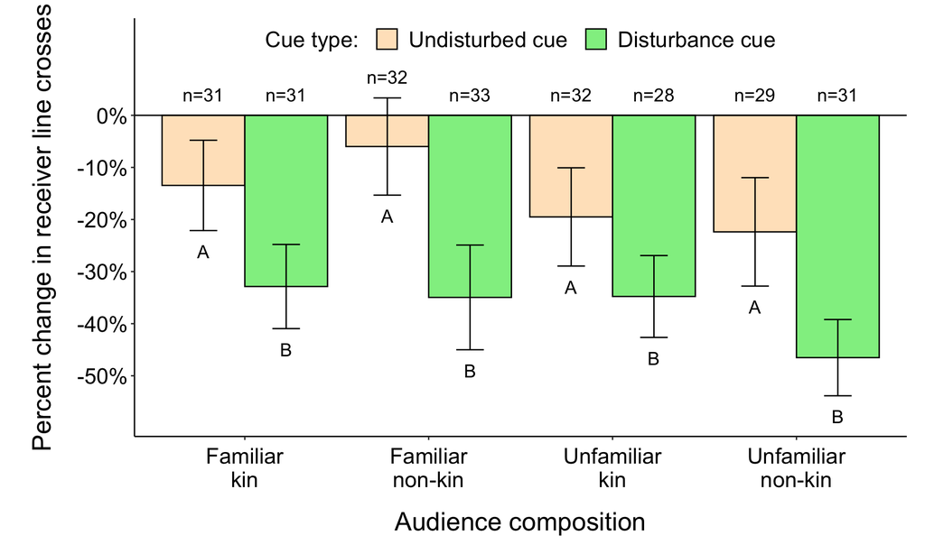

```r
p1 <- data %>% filter(cue!="W") %>%
    within({cue <- factor(cue, levels=c("UC","DC"),
                  labels=c("Undisturbed cue", "Disturbance cue"))}) %>%
    mutate(kinfam = interaction(kinship, familiarity)) %>%
    group_by(kinfam, cue) %>%
    summarise(mean = mean(prop, na.rm=T), se = sd(prop, na.rm=T)/sqrt(n()), n = n()) %>%
    ggplot(aes(x = kinfam, y = mean, fill = cue)) +
    ggtheme +
    geom_bar(position=position_dodge(), stat = "identity", col = "black") +
    geom_errorbar(position=position_dodge(width = 0.9), aes(ymin = mean - se, ymax = mean + se),
              width = 0.3) +
    labs(y="Percent change in receiver line crosses\n", x=NULL) +
    scale_fill_manual(name = "Cue type: ", labels = c("Undisturbed cue ", "Disturbance cue"),
              values = c("bisque", "light green")) +
    scale_y_continuous(limits = c(-0.58, 0.15),
               breaks = seq(-0.5,0,by=0.1),
               labels = scales::percent_format(accuracy = 1)) +
    scale_x_discrete(name = "Audience composition", labels = c("Familiar\nkin", "Familiar\nnon-kin", "Unfamiliar\nkin", "Unfamiliar\nnon-kin")) +
    geom_abline(aes(slope=0, intercept=0)) +
    geom_text(aes(y = ifelse(mean > 0, mean-se-0.04,
                 ifelse(mean+se > 0, mean+se+0.04, 0.04)),
                 label=paste0("n=",n,"")),
          position=position_dodge(width=0.9), size=5) +
    geom_text(aes(y=mean-se-0.04,
              label = rep(c("A", "B"),4)),
          position=position_dodge(width=0.9), size=5)
p1
```

# 2 One-way (cue type) analysis

For the second main analysis, we examine all three cue types, including control water, and thus cannot include familiarity vs. kinship distinctions (water has no familiarity or kin types associated). We proceed similar to the analysis above, using quasipoisson GLMs for pre-exposure counts and proportion change in line crosses for assessing the relative change in tadpole activity for each cue type.

## 2.1 Pre-exposure analysis

```r
cat("Using summary (type I SS):")
```

```
Using summary (type I SS):
```

```r
(m2.pre <- data %>% glm(data=., pre ~ cue, family=quasipoisson)) %>%
    summary
```

```
Call:
glm(formula = pre ~ cue, family = quasipoisson, data = .)

Deviance Residuals:
    Min       1Q   Median       3Q      Max
-3.5548  -2.0381  -0.5437   1.1249   7.2310

Coefficients:
            Estimate Std. Error t value Pr(>|t|)
(Intercept) 2.952315   0.027362 107.898   <2e-16 ***
cue1        0.009926   0.038470   0.258    0.797
cue2        0.003099   0.038690   0.080    0.936
---
Signif. codes:  0 '***' 0.001 '**' 0.01 '*' 0.05 '.' 0.1 ' ' 1

(Dispersion parameter for quasipoisson family taken to be 5.346754)

    Null deviance: 1791.7  on 372  degrees of freedom
Residual deviance: 1791.0  on 370  degrees of freedom
AIC: NA

Number of Fisher Scoring iterations: 4
```

```r
cat("Using drop1 (type III SS):")
```

```
Using drop1 (type III SS):
```

```r
m2.pre %>% drop1("cue", test="F") # F(2, 370) = 0.07, p = 0.93
```

|  | Df | Deviance | F value | Pr(>F) |
| --- | --- | --- | --- | --- |
|  | NA | 1791.041 | NA | NA |
| cue | 2 | 1791.699 | 0.0679809 | 0.93429 |

### 2.1.1 Pre-exposure plot

```r
main2_pre_lines_summary <- data %>%
    mutate(cue = fct_recode(cue, "Control Water" = "W",
                "undisturbed cue"="UC", "disturbance cue"="DC")) %>%
    group_by(kinship, familiarity, cue) %>%
    summarise(n = n(),
          mean_lines = mean(pre),
          sd_lines = sd(pre),
          se_lines = sd(pre)/n())
main2_pre_lines_summary
```

| kinship | familiarity | cue | n | mean_lines | sd_lines | se_lines |
| --- | --- | --- | --- | --- | --- | --- |
| kin | familiar | Control Water | 30 | 16.86667 | 10.811020 | 0.3603673 |
| kin | familiar | undisturbed cue | 31 | 20.38710 | 9.783242 | 0.3155885 |
| kin | familiar | disturbance cue | 31 | 19.09677 | 8.941867 | 0.2884473 |
| kin | unfamiliar | Control Water | 32 | 20.21875 | 10.247689 | 0.3202403 |
| kin | unfamiliar | undisturbed cue | 32 | 17.18750 | 7.706041 | 0.2408138 |
| kin | unfamiliar | disturbance cue | 28 | 17.89286 | 9.064948 | 0.3237481 |
| non-kin | familiar | Control Water | 32 | 22.00000 | 11.959609 | 0.3737378 |
| non-kin | familiar | undisturbed cue | 32 | 17.81250 | 9.956154 | 0.3111298 |
| non-kin | familiar | disturbance cue | 33 | 18.00000 | 9.581884 | 0.2903601 |
| non-kin | unfamiliar | Control Water | 32 | 18.12500 | 10.518034 | 0.3286886 |
| non-kin | unfamiliar | undisturbed cue | 29 | 21.72414 | 11.652396 | 0.4018067 |
| non-kin | unfamiliar | disturbance cue | 31 | 20.58065 | 10.375530 | 0.3346945 |

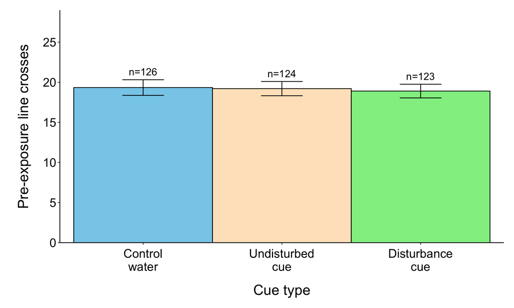

```r
p2.pre <- data %>%
    group_by(cue) %>%
    summarise(mean = mean(pre, na.rm=T),
          se = sd(pre, na.rm=T)/sqrt(n()), n = n()) %>%
    ggplot(aes(x = cue, y = mean, fill = cue)) +
    ggtheme +
    geom_bar(position=position_dodge(width = 0.9), width=1,
         stat = "identity", col = "black") +
    geom_errorbar(position=position_dodge(width = 0.9),
              aes(ymin = mean - se, ymax = mean + se),
              width = 0.3) +
    labs(y="Pre-exposure line crosses\n", x="Cue type") +
    scale_fill_manual(guide = FALSE,
              values = c("skyblue","bisque", "light green")) +
    scale_y_continuous(limits = c(0, 29), breaks = seq(0,25,by=5),
               expand = c(0,0)) +
    scale_x_discrete(labels = c("Control\nwater", "Undisturbed\ncue",
                    "Disturbance\ncue")) +
    geom_abline(aes(slope=0, intercept=0)) +
    geom_text(aes(y = mean+se+1,
              label=paste0("n=",n,"")),
          position=position_dodge(width=0.9), size=5)
p2.pre
```

## 2.2 Proportion change in line crosses analysis

We use a one-way ANOVA to examine differences in the proportion change in line crosses across the three cue types (with its parametric assumptions tested in the next section).

```r
cat("Using summary (type I SS):")
```

```
Using summary (type I SS):
```

```r
data %>% lm(data=., prop ~ cue) %>%
    summary
```

```
Call:
lm(formula = prop ~ cue, data = .)

Residuals:
     Min       1Q   Median       3Q      Max
-0.98356 -0.36772 -0.06176  0.30159  2.37302

Coefficients:
            Estimate Std. Error t value Pr(>|t|)
(Intercept) -0.18041    0.02876  -6.273 9.89e-10 ***
cue1         0.16397    0.04053   4.045 6.37e-05 ***
cue2         0.02865    0.04070   0.704    0.482
---
Signif. codes:  0 '***' 0.001 '**' 0.01 '*' 0.05 '.' 0.1 ' ' 1

Residual standard error: 0.5554 on 370 degrees of freedom
Multiple R-squared:  0.0659,    Adjusted R-squared:  0.06085
F-statistic: 13.05 on 2 and 370 DF,  p-value: 3.331e-06
```

```r
cat("Using drop1 (type III SS):")
```

```
Using drop1 (type III SS):
```

```r
(m2.prop <- data %>% aov(data=., prop ~ cue)) %>%
    drop1("cue", test="F") # F(2,370) = 13.1, P < 0.0001
```

|  | Df | Sum of Sq | RSS | AIC | F value | Pr(>F) |
| --- | --- | --- | --- | --- | --- | --- |
|  | NA | NA | 114.1300 | -435.7216 | NA | NA |
| cue | 2 | 8.052157 | 122.1822 | -414.2924 | 13.05221 | 3.3e-06 |

The cue parameter is significant ($F_{2,370}$ = 13.1, $p$ < 0.0001). We thus use Tukey HSD post-hoc tests to determine which cues are significantly different.

```r
TukeyHSD(m2.prop)
```

```
  Tukey multiple comparisons of means
    95% family-wise confidence level

Fit: aov(formula = prop ~ cue, data = .)

$cue
            diff        lwr         upr     p adj
UC-W  -0.1353233 -0.3006446  0.02999803 0.1327497
DC-W  -0.3565872 -0.5222468 -0.19092749 0.0000019
DC-UC -0.2212639 -0.3875822 -0.05494558 0.0053383
```

```r
# W  vs. UC: P = 0.13
# W  vs. DC: P < 0.0001
# UC vs. DC: P = 0.0053
```

Water and undisturbed cue are not significantly different (Tukey HSD, $p$ = 0.13), but disturbance cues elicit a significantly lower proportion change in line crosses relative to water ($p$ < 0.0001) and undisturbed cues ($p$ = 0.0053).

```r
## Analysis on post - pre difference ##
# Not run: same analysis, using difference in line crosses instead of proportion line crosses
cat("Using summary (type I SS):")
data %>% lm(data=., diff ~ cue) %>%
    summary # same outcome

cat("Using drop1 (type III SS):")
(m2.diff <- data %>% aov(data=., diff ~ cue)) %>%
    drop1("cue", test="F") # F(2,370) = 8.45, P = 0.0003

TukeyHSD(m2.diff)
# W  vs. UC: P = 0.84
# W  vs. DC: P = 0.0005
# UC vs. DC: P = 0.0036
```

### 2.2.1 Parametric assumptions

Next, we test the normality and homogeneity of variances for the ANOVA model by assessing the distribution of model residuals.

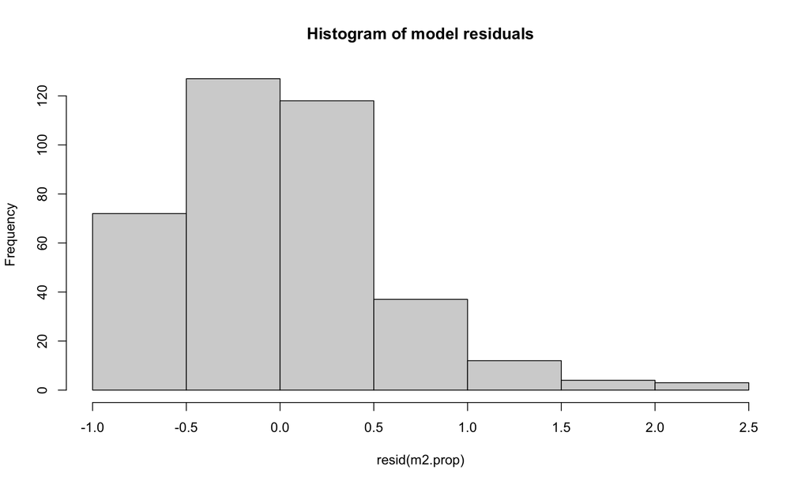

```r
# normality:
hist(resid(m2.prop), main="Histogram of model residuals")
```

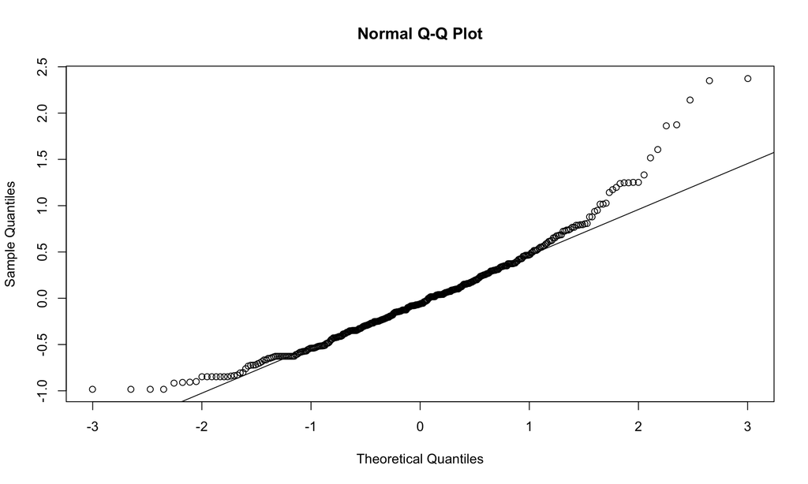

```r
qqnorm(resid(m2.prop)); qqline(resid(m2.prop))
```

```r
ks.test(resid(m2.prop), "pnorm", mean = mean(resid(m2.prop)), sd = sd(resid(m2.prop)))
```

```
    One-sample Kolmogorov-Smirnov test

data:  resid(m2.prop)
D = 0.066225, p-value = 0.07588
alternative hypothesis: two-sided
```

```r
# homoscedasticity:
data %>% car::leveneTest(prop  ~ cue * familiarity * kinship, data=.)
```

|  | Df | F value | Pr(>F) |
| --- | --- | --- | --- |
| group | 11 | 0.8996312 | 0.5408691 |
|  | 361 | NA | NA |

Despite the slight skew in the residuals, the data are roughly normally-distributed (Kolmogorov-Smirnov test, D = 0.066, $p$ = 0.08), and ANOVA procedures are relatively robust to deviances from normality [Kirk, RE (1995). Experimental Design: Procedures For The Behavioral Sciences (3 ed.). Pacific Grove, CA, USA: Brooks/Cole]. Further, the assumption of homoscedasticity is upheld (Levene’s $F_{11,361}$ = 0.90. $p$ = 0.54).

### 2.2.2 Effect sizes

```r
### effect sizes:
main2_summary <- data %>%
    pivot_longer(cols=pre:prop) %>%
    group_by(cue, name) %>%
    summarise(mean = mean(value, na.rm=T),
          se = sd(value, na.rm=T)/sqrt(n()),
          n = n()) %>%
    pivot_wider(id_cols=c(cue, n),
            names_from=name, values_from=c(mean,se), names_sort=T) %>%
    relocate(c(mean_pre, se_pre), .after=n) %>%
    relocate(c(mean_post, se_post), .after=se_pre) %>%
    relocate(c(mean_prop, se_prop), .after=se_post)
main2_summary
```

| cue | n | mean_pre | se_pre | mean_post | se_post | mean_prop | se_prop | mean_diff | se_diff |
| --- | --- | --- | --- | --- | --- | --- | --- | --- | --- |
| W | 126 | 19.34127 | 0.9755853 | 16.76984 | 1.0974234 | -0.0164361 | 0.0583634 | -2.571429 | 1.0008522 |
| UC | 124 | 19.20968 | 0.8872493 | 15.91935 | 1.0458037 | -0.1517593 | 0.0470299 | -3.290323 | 0.8626327 |
| DC | 123 | 18.90244 | 0.8534034 | 11.38211 | 0.8583946 | -0.3730232 | 0.0422183 | -7.520325 | 0.8803806 |

```r
# Additional comparisons referenced in-text:
main2_summary$mean_prop[3]/main2_summary$mean_prop[1] # ~23 fold greater response
main2_summary$mean_prop[3]/main2_summary$mean_prop[2] # ~2.5 fold greater response
main2_summary$mean_prop[3]*100 # 37% mean reduction due to DCs
data %>% filter(cue != "DC") %>% summarise(mean = mean(prop, na.rm=T))*100
# 8% mean reduction due to UC & W
-37.30232/-8.355641 # ~4.5-fold higher response to DC vs. UC/W
```

### 2.2.3 Percent change plot

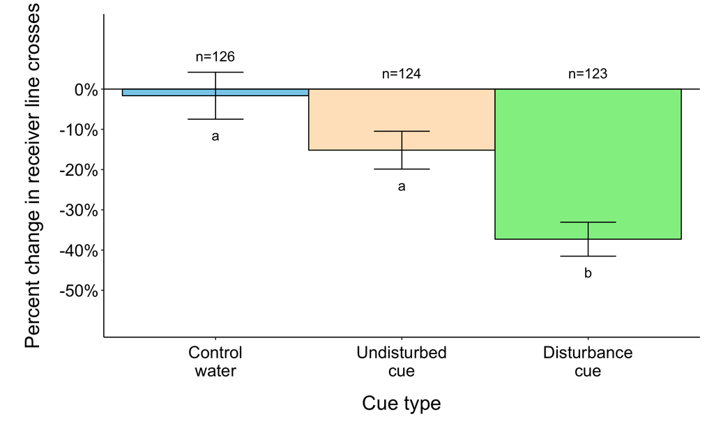

```r
p2 <- data %>%
    group_by(cue) %>%
    summarise(mean = mean(prop, na.rm=T), se = sd(prop, na.rm=T)/sqrt(n()), n = n()) %>%
    ggplot(aes(x = cue, y = mean, fill = cue)) +
    ggtheme +
    geom_bar(position=position_dodge(width = 0.9), width=1, stat = "identity", col = "black") +
    geom_errorbar(position=position_dodge(width = 0.9), aes(ymin = mean - se, ymax = mean + se),
              width = 0.3) +
    labs(y="Percent change in receiver line crosses\n", x="Cue type") +
    scale_fill_manual(guide = FALSE, values = c("skyblue", "bisque", "light green")) + # also this one:
    scale_y_continuous(limits = c(-0.58, 0.15),
               breaks = seq(-0.5,0,by=0.1),
               labels = scales::percent_format(accuracy = 1)) +
    scale_x_discrete(labels = c("Control\nwater", "Undisturbed\ncue", "Disturbance\ncue")) +
    geom_abline(aes(slope=0, intercept=0)) +
    geom_text(aes(y = ifelse(mean > 0, mean-se-0.04,
                 ifelse(mean+se > 0, mean+se+0.04, 0.04)),
                 label=paste0("n=",n,"")),
          position=position_dodge(width=0.9), size=5) +
    geom_text(aes(y=mean-se-0.04,
              label = c("a", "a","b")),
          position=position_dodge(width=0.9), size=5)
p2
```

# 3 Final plots

## 3.1 Manuscript Figure 2

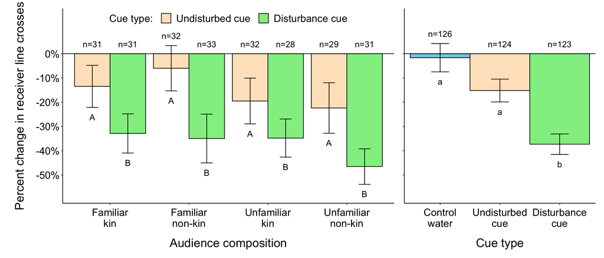

```r
# setEPS()
# postscript("Fig2.eps", width = 14, height = 6)
grid.arrange(as.grob(p1), as.grob(p2 + theme(axis.text.y=element_blank()) + labs(y=NULL)), layout_matrix=t(as.matrix(c(1,1,2))))
```

```r
# dev.off()
```

## 3.2 Supplementary Figure 1

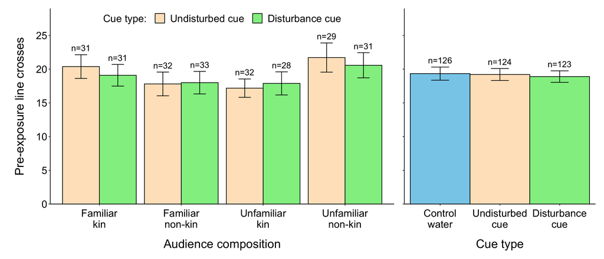

```r
# setEPS()
# postscript("FigS1.eps", width = 14, height = 6)
grid.arrange(as.grob(p1.pre), as.grob(p2.pre + theme(axis.text.y=element_blank()) + labs(y=NULL)), layout_matrix=t(as.matrix(c(1,1,2))))
```

```r
# dev.off()
```